# R Notebook

# How do sites vary in their nutrient resource profiles?

As a starting point, I characterized sites by their resource availability to get a better sense of the variation in resource supply across sites, as well as correlation between the three potential limiting resources manipulated through fertilization.

```r
# Subsetting species matrix by these site codes
soil.chars = soil.chars %>%
  filter(year_trt == 0) %>%
  mutate(block = as.factor(block),
         plot = as.factor(plot))

# Selecting parameters of interest
soil.stdized = soil.chars %>%
  select(site_code, block, plot, pct_N, pct_C, ppm_P, ppm_K) %>%
  na.omit() %>%
  # Log-transform prior to calculate total resource availability? Or wait?
  mutate_if(is.numeric, log)

# Function to calculate network-wide site z-scores
calc_zscores <- function(x){(x - mean(na.omit(x))) / sd(na.omit(x))}

# Z-scoring variation
soil.zscores = soil.stdized %>%
  mutate_if(is.numeric, calc_zscores)

pairs(soil.zscores %>%
  select(pct_N, ppm_P, ppm_K))

solve(cor(soil.zscores %>%
  select(pct_N, ppm_P, ppm_K, pct_C)))
```

[output not shown]

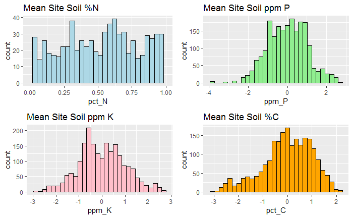

```r
# Plotting relative site resource availability
p1 = soil.zscores %>% ggplot(aes(x = pct_N)) +
  geom_histogram(color = "black", fill = "lightblue") +
  xlim(0, 1)+
  ggtitle("Mean Site Soil %N")
p2 =  soil.zscores %>% ggplot(aes(x = ppm_P)) +
  geom_histogram(color = "black", fill = "lightgreen") +
  ggtitle("Mean Site Soil ppm P")
p3 = soil.zscores %>% ggplot(aes(x = ppm_K)) +
  geom_histogram(color = "black", fill = "pink") +
  ggtitle("Mean Site Soil ppm K")
p4 = soil.zscores %>% ggplot(aes(x = pct_C)) +
  geom_histogram(color = "black", fill = "orange") +
  ggtitle("Mean Site Soil %C")
gridExtra::grid.arrange(p1, p2, p3, p4, nrow = 2)
```

# Calculating site stoichiometric ratios

To characterize sites by their relative resource supply and imbalance, we can calculate both the total amount of resources available in a given site, as well as the relative imbalance of these ratios, per Cardinale et al. (2009).

In this method, site resource concentrations of any $n$ nutrients are standardized to their $z$-scores, then projected onto a vector ($\vec{1}$) that represents a perfect balance of resource stoichiometry.

In a two-resource example, see panel (a) in the figure below from Lewandoska et al. (2016)

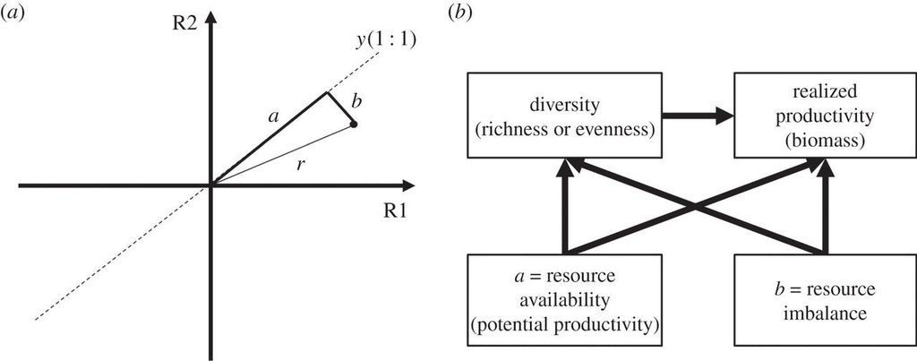

This schematic shows some site resource concentrations in resources 1 and 2, denoted by the vector $r$, projected upon a “perfectly balanced” vector denoted by $a$. The length of this projection, $a$, represents total resource supply in the system, while the orthogonal vector, $b$ represents resource imbalance.

As an aside, I think there’s an error in the caption of this figure, where $b$ is listed as a function of cosh(), which should produce an angle, $\theta$. This measure of $\theta$ is likely what is actually being used, as is the case in the original Cardinale et al 2009. I’ve listed the formula below:

$$\theta = \cos^{-1}\frac{(\vec{x} \cdot \vec{y})}{\left\lVert\vec{x}
\right\rVert \left\lVert\vec{y}\right\rVert} = \cos^{-1}\frac{a}{r}$$

I haven’t seen this done before in other publications, but I believe we can also use this information to figure out what is limiting relative to this ideal stoichiometric ratio. The vector $b$, which is the portion of our observed vector $r$ that is not accounted for by the projection onto $a$ can be termed the “rejection”, defined simply by $b = r - a$

[figure not shown]